# Homeworks 03

Marco Zullich

May 11, 2019

```r
library(rstan)
library(rstanarm)
library(dplyr)
```

```r
library(ggplot2)
library(bayesplot)
library(data.table)
knitr::opts_chunk$set(echo = TRUE)
theme_set(bayesplot::theme_default())
rstan_options(auto_write=TRUE)
```

# TH-1

Since in the `R` script there’re missing packages, the script was modified and renamed as `4.7_Fitting a series of regressions_trimmed.R`. The only significant update was:

- added reference to `foreign` package for method `read.dta`
- commented everything from line 34 on since not needed for data loading and wranglin

We start by loading the light script:

```r
source("4.7_Fitting a series of regressions_trimmed.R")
```

```
##
## arm (Version 1.10-1, built: 2018-4-12)
```

```
## Working directory is C:/Users/zuzzu/OneDrive/Documenti/Bayes/Exercizes/ex03
```

then we finish updating the data as in the `gl_regression_script.R` script:

```r
yr <- 1992
ok <- nes.year==yr & data$presvote<3
vote <- data$presvote[ok] - 1
income <- data$income[ok]

vote = vote %>% as_tibble() %>% filter(!is.na(vote))
income = income %>% as_tibble() %>% filter(!is.na(income))
```

Then we produce the `Stan` script `1992polls_probit.stan` to state the probit model we wish to estimate:

```
data{
  int N;          // number of voters
  int vote[N];    // vote: 0 (Clinton), 1 (Bush)
  int income[N];  // 1-5 income scale
}
parameters{
  real alpha;    // intercept
  real beta;     // income coefficient
}
model{
  //alpha ~ normal(0,10);
  //beta ~ normal(0,2.5);
  //for(i in 1:N){
  //  vote[i] ~ bernoulli(Phi(alpha + beta*income[i]));
  //}
  target += normal_lpdf(alpha | 0, 10);
  target += normal_lpdf(beta | 0, 2.5);
  for(i in 1:N){
    target += bernoulli_lpmf(vote[i]  | Phi(alpha + income[i]*beta));
  }

}

generated quantities{
  vector[N] y_rep;
  for (n in 1:N) {
    real eta_n = alpha + beta * income[n];
    y_rep[n] = bernoulli_rng(Phi(eta_n));
  }
}
```

We compile the model

```r
probit_1992polls = stan_model('1992polls_probit.stan')
```

We then create the data for the Stan model as a list:

```r
stan_data_1992polls = list(
  N=nrow(vote),
  vote = vote %>% pull(),
  income = income %>% pull()
)
```

And run the model

```r
probit_1992polls_fit = sampling(probit_1992polls, data = stan_data_1992polls, cores = 4)
# default sample size is 2000, but we burn in the 50% of it
```

Now that the sampling has finished, we have a look at the coefficients $\alpha$ and $\beta$:

```r
print(probit_1992polls_fit, pars=c("alpha","beta"))
```

```
## Inference for Stan model: 1992polls_probit.
## 4 chains, each with iter=2000; warmup=1000; thin=1;
## post-warmup draws per chain=1000, total post-warmup draws=4000.
##
##        mean se_mean   sd  2.5%   25%   50%   75% 97.5% n_eff Rhat
## alpha -0.87       0 0.12 -1.10 -0.94 -0.87 -0.79 -0.65   751    1
## beta   0.20       0 0.04  0.14  0.18  0.20  0.22  0.27   747    1
##
## Samples were drawn using NUTS(diag_e) at Tue Jun 04 17:44:37 2019.
## For each parameter, n_eff is a crude measure of effective sample size,
## and Rhat is the potential scale reduction factor on split chains (at
## convergence, Rhat=1).
```

Interpretation of direct effect of the variables on the probability is frail due to the probit link between linear predictor and response; nevertheless, we can say that a unitary increment for the income results in a positive increment of 0.2 on the linear predictor: eventually, there’s still a weak positive effect on the probability of voting Republicans. The parameter alpha may be interpreted as follows: a zero income results in a low probability of voting Republican, exactly $\Phi(-.87)\approx 0.19$.

The results are different wrt the logistic model ($\alpha=-1.4,\ \beta=0.3$). This complies with the expectation that probit model yields coefficients which are approximately the ones obtained in the logistic model, divided by 1.6 ($-1.4/1.6 = -0.875 \approx -0.87;\ .3/1.6=.1875\approx.2$); moreover, the coefficients have the same sign, which means that the positive/negative effect on the probability of voting still stands.

Just a quick check on the model’s goodness of fit:

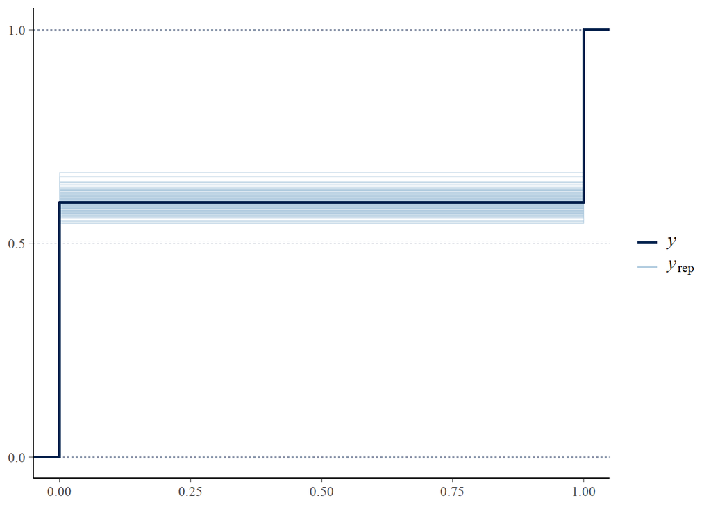

```r
y_rep <- as.matrix(probit_1992polls_fit, pars = "y_rep")
ppc_ecdf_overlay(y = stan_data_1992polls$vote, y_rep[1:200,], discrete=TRUE)
```

We see that the model’s goodness of fit is nice, since the original observations `y` fall into the distribution yielded by the model’s `y_rep`s.

To complete the exercise, we fit the same model, this time using the `rstanarm` package:

```r
probit_1992polls_fit_rstanarm = stan_glm(vote ~ income,
                                         family = binomial(link='probit'),
                                         data = stan_data_1992polls %>% as.data.frame(),
                                         prior_intercept = normal(0,10),
                                         prior = normal(0,2.5),
                                         cores = 4)

summary(probit_1992polls_fit_rstanarm)
```

```
##
## Model Info:
##
##  function:     stan_glm
##  family:       binomial [probit]
##  formula:      vote ~ income
##  algorithm:    sampling
##  priors:       see help('prior_summary')
##  sample:       4000 (posterior sample size)
##  observations: 1179
##  predictors:   2
##
## Estimates:
##                 mean   sd     2.5%   25%    50%    75%    97.5%
## (Intercept)     -0.9    0.1   -1.1   -0.9   -0.9   -0.8   -0.7
## income           0.2    0.0    0.1    0.2    0.2    0.2    0.3
## mean_PPD         0.4    0.0    0.4    0.4    0.4    0.4    0.4
## log-posterior -784.0    1.0 -786.9 -784.4 -783.7 -783.3 -783.1
##
## Diagnostics:
##               mcse Rhat n_eff
## (Intercept)   0.0  1.0  2805
## income        0.0  1.0  2938
## mean_PPD      0.0  1.0  3367
## log-posterior 0.0  1.0  1760
##
## For each parameter, mcse is Monte Carlo standard error, n_eff is a crude measure of effective sample size, and Rhat is the potential scale reduction factor on split chains (at convergence Rhat=1).
```